# Regression Analysis of Company Performance

GROUP:7  
RAHUL GUNDEKARI  
HRUDHAYESH DONIKALA

# Introduction

In the current competitive business landscape, understanding the factors that drive profitability is crucial for any company. By leveraging statistical models, we can uncover the relationships between various spending strategies and overall financial success. In this presentation, we delve into a dataset comprising several companies’ spendings on research and development (R&D), administration, and marketing, along with their respective profits.

# Question of Interest

- What role does marketing and administrative spending play in profitability?
- Are there state-wise variations in how these factors affect profits?

By examining these questions through the lens of regression analysis, we will not only gain insights into effective spending strategies but also forecast future profits based on current spending patterns

# Install packages (Installing required packages)

install.packages(“dplyr”) install.packages(“tidyverse”) install.packages(“caret”) install.packages(“caTools”) library(caret) library(dplyr) library(caTools)

# Data Understanding

```r
data <- read.csv("C:\\Users\\RAHUL\\Downloads\\Regression data.csv")
data
```

```
##    R.D.Spend Administration Marketing.Spend      State    Profit
## 1  165349.20      136897.80       471784.10   New York 192261.83
## 2  162597.70      151377.59       443898.53 California 191792.06
## 3  153441.51      101145.55       407934.54    Florida 191050.39
## 4  144372.41      118671.85       383199.62   New York 182901.99
## 5  142107.34       91391.77       366168.42    Florida 166187.94
## 6  131876.90       99814.71       362861.36   New York 156991.12
## 7  134615.46      147198.87       127716.82 California 156122.51
## 8  130298.13      145530.06       323876.68    Florida 155752.60
## 9  120542.52      148718.95       311613.29   New York 152211.77
## 10 123334.88      108679.17       304981.62 California 149759.96
## 11 101913.08      110594.11       229160.95    Florida 146121.95
## 12 100671.96       91790.61       249744.55 California 144259.40
## 13  93863.75      127320.38       249839.44    Florida 141585.52
## 14  91992.39      135495.07       252664.93 California 134307.35
```

[output cut: 36 more lines]

# Checking for Null values

```
##       R.D.Spend  Administration Marketing.Spend           State          Profit
##               0               0               0               0               0
```

# Dataset Description

- **R.D.Spend**: Shows Financial expenditure on development and research activities
- **Administration**: Displays the administrative expenses for different companies
- **Marketing.Spend**: Investment in marketing and promotional activities
- **State**: The U.S. states where the company’s operations are based.
- **Profit**: Shows the profit of the companies as per state

# Summary of data

```r
# Summary of the data
summary(data)
```

```
##    R.D.Spend      Administration   Marketing.Spend     State
##  Min.   :     0   Min.   : 51283   Min.   :     0   Length:50
##  1st Qu.: 39936   1st Qu.:103731   1st Qu.:129300   Class :character
##  Median : 73051   Median :122700   Median :212716   Mode  :character
##  Mean   : 73722   Mean   :121345   Mean   :211025
##  3rd Qu.:101603   3rd Qu.:144842   3rd Qu.:299469
##  Max.   :165349   Max.   :182646   Max.   :471784
##      Profit
##  Min.   : 14681
##  1st Qu.: 90139
##  Median :107978
##  Mean   :112013
##  3rd Qu.:139766
##  Max.   :192262
```

# EDA (Exploratory Data Analysis)

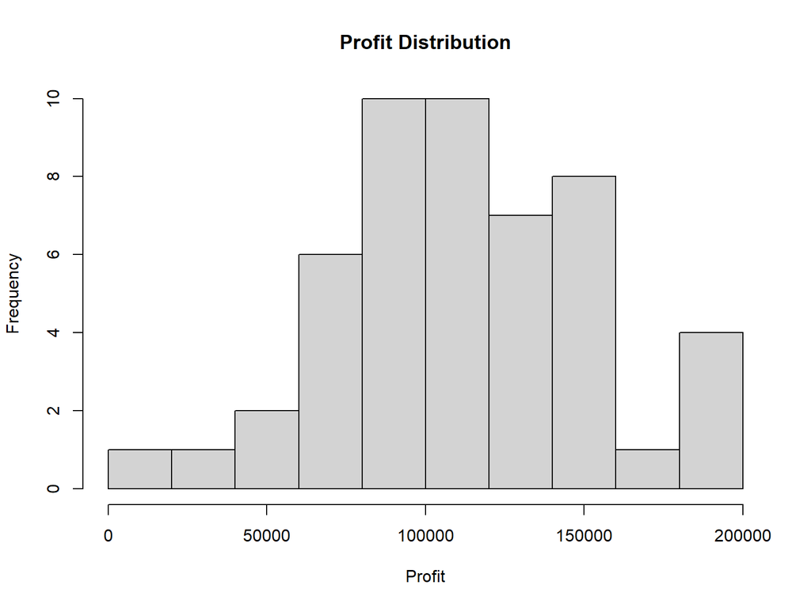

```r
# Plotting histograms
hist(data$Profit, main="Profit Distribution", xlab="Profit")
```

# Histogram of R.D spend Distribuition

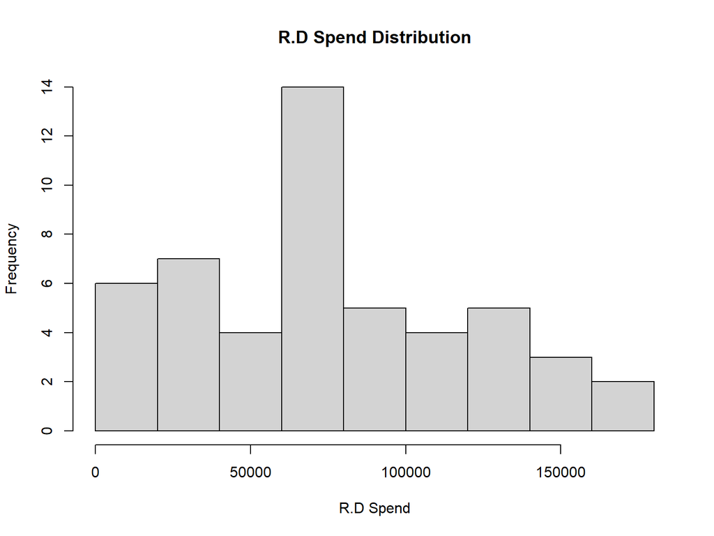

```r
hist(data$R.D.Spend, main="R.D Spend Distribution", xlab="R.D Spend")
```

# Boxplot of Profit according to states

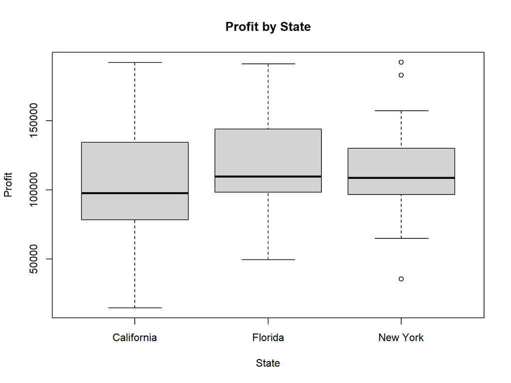

```r
# Boxplots for understanding distributions across states
boxplot(Profit ~ State, data=data, main="Profit by State")
```

# Correlation Matrix

```r
cor(data[, c("R.D.Spend", "Administration", "Marketing.Spend", "Profit")])
```

```
##                 R.D.Spend Administration Marketing.Spend    Profit
## R.D.Spend       1.0000000     0.24195525      0.72424813 0.9729005
## Administration  0.2419552     1.00000000     -0.03215388 0.2007166
## Marketing.Spend 0.7242481    -0.03215388      1.00000000 0.7477657
## Profit          0.9729005     0.20071657      0.74776572 1.0000000
```

# Linear regression model, Coefficients

#Multiple regression = (Y =β0+β1X1+β2X2+β3X3+ϵ)

```r
model <- lm(Profit ~ R.D.Spend + Administration + Marketing.Spend + State, data=data)
```

```r
# Summary of the model to check coefficients and statistics
summary(model)
```

```
##
## Call:
## lm(formula = Profit ~ R.D.Spend + Administration + Marketing.Spend +
##     State, data = data)
##
## Residuals:
##    Min     1Q Median     3Q    Max
## -33504  -4736     90   6672  17338
##
## Coefficients:
##                   Estimate Std. Error t value Pr(>|t|)
## (Intercept)      5.013e+04  6.885e+03   7.281 4.44e-09 ***
## R.D.Spend        8.060e-01  4.641e-02  17.369  < 2e-16 ***
## Administration  -2.700e-02  5.223e-02  -0.517    0.608
## Marketing.Spend  2.698e-02  1.714e-02   1.574    0.123
## StateFlorida     1.988e+02  3.371e+03   0.059    0.953
## StateNew York   -4.189e+01  3.256e+03  -0.013    0.990
## ---
## Signif. codes:  0 '***' 0.001 '**' 0.01 '*' 0.05 '.' 0.1 ' ' 1
##
## Residual standard error: 9439 on 44 degrees of freedom
## Multiple R-squared:  0.9508, Adjusted R-squared:  0.9452
## F-statistic: 169.9 on 5 and 44 DF,  p-value: < 2.2e-16
```

# Assumption validation

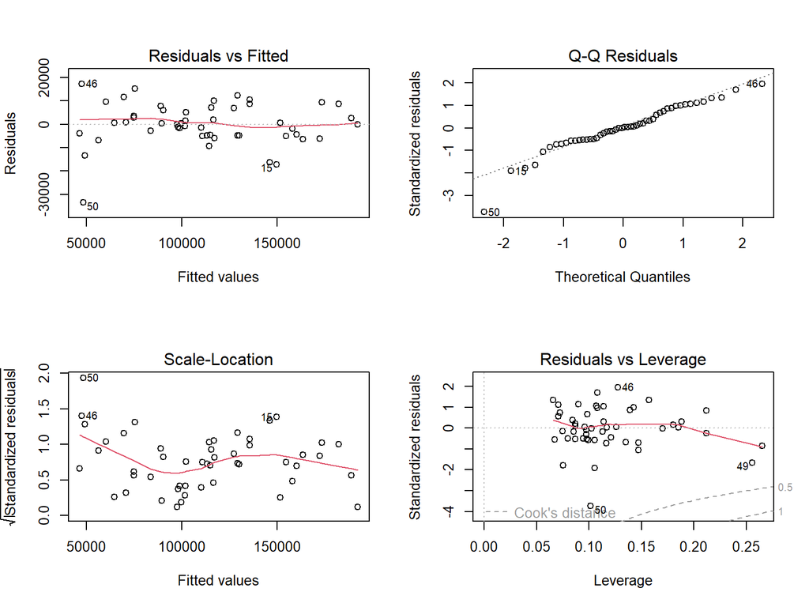

# Check for normality through histogram

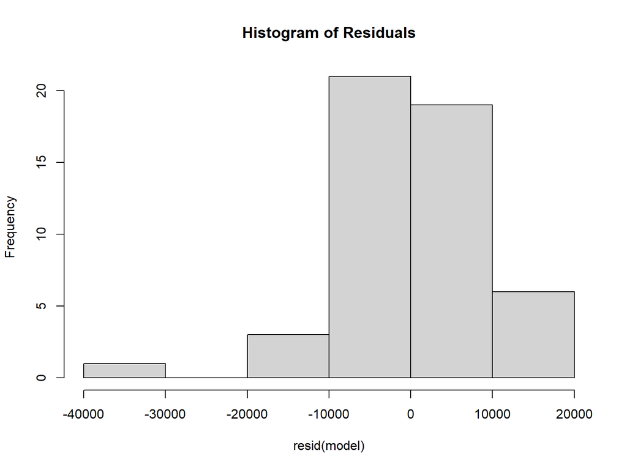

# Here, this code shows training the dataset and testing it. Moreover, performs linear regression model

```
##
## Call:
## lm(formula = Profit ~ ., data = trainingSet)
##
## Residuals:
##      Min       1Q   Median       3Q      Max
## -30863.4  -5769.4    213.8   5909.8  15488.7
##
## Coefficients:
##                   Estimate Std. Error t value Pr(>|t|)
## (Intercept)      4.540e+04  7.525e+03   6.034 9.85e-07 ***
## R.D.Spend        8.246e-01  5.119e-02  16.108  < 2e-16 ***
## Administration  -1.131e-02  5.753e-02  -0.197    0.845
## Marketing.Spend  3.241e-02  1.967e-02   1.648    0.109
## StateFlorida     1.100e+03  3.834e+03   0.287    0.776
## StateNew York   -8.772e+02  3.730e+03  -0.235    0.816
## ---
## Signif. codes:  0 '***' 0.001 '**' 0.01 '*' 0.05 '.' 0.1 ' ' 1
##
## Residual standard error: 9384 on 32 degrees of freedom
## Multiple R-squared:  0.9587, Adjusted R-squared:  0.9522
## F-statistic: 148.4 on 5 and 32 DF,  p-value: < 2.2e-16
```

# Calculating the Root Mean Squared Error(RMSE)

```
## [1] "Root Mean Squared Error (RMSE): 10229.2316072654"
```

# Calculating R-Squared

```
## [1] "R-squared: 0.889570847769099"
```

# Conclusion

-> R-squared value 0.8895 which states that the predictors selected have explained 88% of the variance of the target variable “Profit”.

-> Our regression analysis revealed significant insights into the factors affecting company profits. The R.D Spend emerged as a significant predictor, indicating a strong positive correlation with Profit.

-> For every unit increase in R&D Spend, there was a corresponding increase in Profit, suggesting that investments in research and development are likely to yield financial benefits.

# Reference/ Source

Taken help from AI tool called “chatGpt” at “assumption validation” stage.